# EAI Practicum 2.1

## Regression Problems

In the following exercise we’ll use the FIFA data set containing information on 19 239 players enrolled in the season of 22, including columns related to: `short_name`, `role`, `preferred_foot`, `player_positions`, `wage_eur`, `value_eur`, `overall` and all attribute names starting with `skill`.

### Modelling Aims

Our goal is to predict the values of **overall** of an **offensive** **player** based on information we have, such as his **skill** characteristics, foot preference, etc.

The process of building a regression model is simple and is referred to as *model fitting*. Although different types of machine learning have different approaches, there are several common steps that are used by most modelling scenarios, not just the regression ones. Be sure to include these steps to get the job done. You need to:

- understand your data and make a good data budgeting choice (not discussed here),
- know how to chose the modeling function with the right formula,
- capture and extract information from any object that a modeling function creates,
- aggregate and interpret the model performance metrics,
- and validate your findings on fresh data.

### Data Loading

**Task 1:** Load `players_22.csv` data into R by completing the missing code.

```r
library(tidyverse)
library(magrittr)

setwd("...") # Set the correct path to players_22.csv
data <- read_csv("players_22.csv", col_names = TRUE, num_threads = 4) # Read data into R
data # Check that data are properly loaded
```

### Data Transformation

A quick glance onto data tells us that there are several `player_positions` per record.

```r
data["player_positions"] %>% head(n=5)
```

```
## # A tibble: 5 × 1
##   player_positions
##   <chr>
## 1 RW, ST, CF
## 2 ST
## 3 ST, LW
## 4 LW, CAM
## 5 CM, CAM
```

We see that our `data` are not tidy and it is a problem. Normally, any player rotates between different positions depending on the overall strategy of a game, but for this exercise only one of four classes is allowed per player: offense, defense, a midfielder position or a goal keeper.

It is ultimately up to you how you define these categories, but we can provide some hints. Offensive players are strikers `ST`, wingers: `RW`, `LW` (W as wingers), central forwarders `CF` and central attacking midfielders, or `CAM`s. Defensive players are `LB` (L as left, B as back), `LWB`, `RB`, `RWB`, `RB` and central defending midfielder `CDM` - these are all positions dedicated to stop the opponent’s advance. `GK` are goal keepers. Everyone else plays as midfielder..

**Task 2:** Complete the code below. Use `mutate()` to create a new column `role`, containing the player’s role (offense, defense, midfielder, goal keeper) based on his attributes in `player_positions`. You can use `%like%` (from library data.table) inside `case_when()` to grep one of multiple player positions. `%<>%` represents bi-directional pipe.

```r
library(data.table) # Implements the %like% operator

data %<>% mutate(
  role = case_when(
    ... # Place your code here...
    .default = "midfielder"
  )
)
```

**Task 3:** Complete the code below. Restrict `data` to `short_name`, `role`, `preferred_foot`, `player_positions`, `wage_eur`, `value_eur`, `overall` and all columns starting with “skill”.

```r
data %<>% ... # Fill in your code here
```

Your data should look like:

```
## # A tibble: 5 × 13
##   short_name    role  preferred_foot player_positions wage_eur value_eur overall
##   <chr>         <chr> <chr>          <chr>               <dbl>     <dbl>   <dbl>
## 1 L. Messi      offe… Left           RW, ST, CF         320000  78000000      93
## 2 R. Lewandows… offe… Right          ST                 270000 119500000      92
## 3 Cristiano Ro… offe… Right          ST, LW             270000  45000000      91
## 4 Neymar Jr     offe… Right          LW, CAM            270000 129000000      91
## 5 K. De Bruyne  offe… Right          CM, CAM            350000 125500000      91
## # ℹ 6 more variables: skill_moves <dbl>, skill_dribbling <dbl>,
## #   skill_curve <dbl>, skill_fk_accuracy <dbl>, skill_long_passing <dbl>,
## #   skill_ball_control <dbl>
```

### Data Exploration

A player’s value stems from his `overall` score, but how a player’s score is affected by his skills? Which skill or skills make a good striker? Or which skills make a good midfielder? Is it only one skill, or a combination of many? Let’ find out.

Your task is to formalize a relation between the value of player’s **skill** and player’s **score** and use this formula to predict offensive player’s score from new data. To do that, let’s inspect `data` for any obvious pattern:

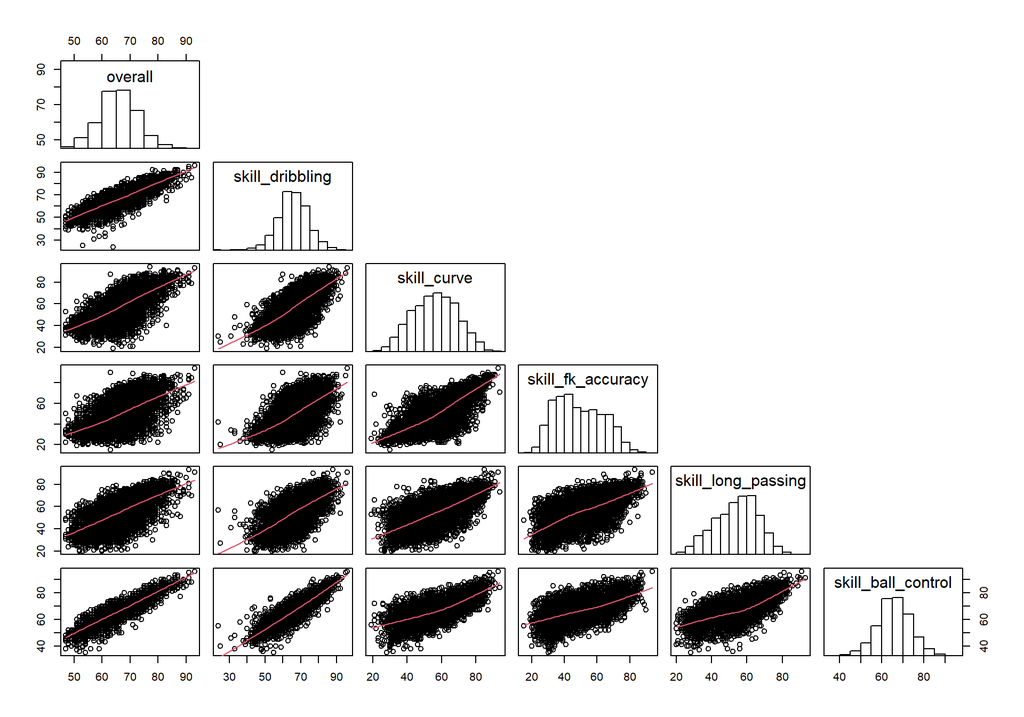

```r
#-----Helper functions-----
panel.cor <- function(x,y, digits=2, prefix="", cex.cor){
  usr <- par("usr")
  on.exit(par(usr))
  par(usr = c(0,1,0,1))
  r <- abs(cor(x,y,use="complete.obs"))
  txt <- format(c(r,0.123456789), digits = digits)[1]
  txt <- paste0(prefix, txt,sep="")
  if(missing(cex.cor)) cex.cor <- 0.8/strwidth(txt)
  text(0.5, 0.5, txt, cex = cex.cor * (1 + r) / 2)
}

panel.hist <- function(x, ...){
  usr <- par("usr")
  on.exit(par(usr))
  par(usr = c(usr[1:2],0,1.5))
  h <- hist(x, plot = FALSE)
  breaks <- h$breaks
  nB <- length(breaks)
  y <- h$counts
  y <- y/max(y)
  rect(breaks[-nB], 0, breaks[-1], y, col="white",...)
}

panel.lm <- function(x,y,col = par("col"), bg = NA, pch = par("pch"),
                     cex = 1, col.smooth = "blue",...){
  points(x,y,pch=pch, col=col(alpha = 0.1), bg=bg, cex=cex)
  abline(stats::lm(x ~ y), col = "steelblue", ...)
}

#-----Pair plot-----
data %>%
  dplyr::filter(role == "offense") %$%
  pairs( ~ overall + skill_dribbling + skill_curve + skill_fk_accuracy +
           skill_long_passing + skill_ball_control, # Omit skill_moves from plotting
         upper.panel= NULL,
         diag.panel=panel.hist,
         lower.panel=panel.smooth)
```

We can now summarize the relationship between values of all possible pairs of attributes. As skill values increase, the overall player’s score increases as well, and the increase can be roughly described by straight line.

Moreover, every pair of attributes seems to be correlated, implying that picking one attribute is enough to model the relation of X (independent variable `skill`) and Y (dependent variable `overall`). Since we are looking for fitting a straight line with the least scatter, we select `skill_dribbling` or `skill_ball_control` for further analysis.

### Hypothesis Formulation

Skill dribbling stands for the player’s ability to pass through defense and get in position with the chance of scoring. It is the trait what the attackers are selected for. Let’s see if our data confirms that.

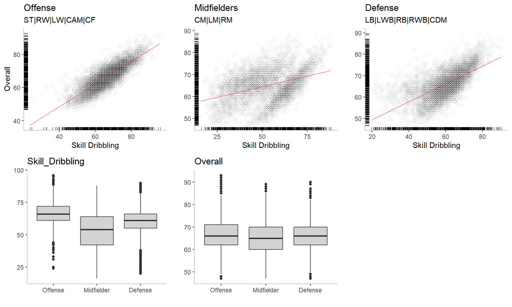

The data show a fairly linear trend for each player class. However, an attacker overall value seem to be more affected by higher dribbling (the slope of a fitted line is steeper) than a defender or a midfielder. If you are into football scouting business, you might be interested in formulating two null hypotheses:

- H<sub>0</sub>: Skill dribbling has no effect on the overall value of an offensive player.
- H<sub>0</sub>: There is no difference between the left and right footed players (in case you are searching for new Maradona).

In the next section, we are going to investigate both by fitting a multiple regression model.

### Model Fitting

Suppose that fitting **an ordinary linear regression model** is our choice. This is equivalent to specifying that the outcome data is numeric (which `overall` is) and that the predictors are related to the outcome in terms of simple slopes and intercepts.
$$y_i = \beta_0 + \beta_1x_1 +
...+ \beta_px_{pi}$$

To fit an ordinary linear regression model in R, you can use the `lm()` function. There are two important arguments to this function: a *model formula* and *data*. The formula is *symbolic*.

For example, the simple formula:

- **`overall ~ skill_dribbling`** specifies that the player’s `overall` score is the *outcome* (since it is on the left-hand side of the tilde `~`) and that the `skill_dribbling` value is the *predictor*.

The formula can be extended by adding an additional predictor; e.g. for `preferred_foot`, which will be internally encoded numerically. Adding foot preference information to the model does not mean that `skill_dribbling` and encoded class of `preferred_foot` are added together. This formula would symbolically represent that `skill_dribbling` and `preferred_foot` should be added as separate *main effects* to the model. We can use **+** inside the formula:

- **`overall ~ skill_dribbling + preferred_foot`** to acknowledge the effect of two predictors. This means that for every unit we move on the axis x, there will be two additive effects impacting how much we travel on the y-axis.

**Task 4:** Complete the code below. Create an ordinary linear regression model. Use `overall` as a dependent variable and `skill_dribbling` and `preferred_foot` as predictors (aka independent variables). Apply the `summary()` function to a model object for getting the verbose readout.

```r
model <- data %>%
  select(...)  %$% # Select offensive players
  lm(...) # Formalize model parameters

summary(...) # Get more detailed statistics of a model fit
```

Inspect the model parameters below.

```
##
## Call:
## lm(formula = overall ~ skill_dribbling + preferred_foot)
##
## Residuals:
##      Min       1Q   Median       3Q      Max
## -12.5725  -2.4596  -0.1412   2.2220  26.5764
##
## Coefficients:
##                      Estimate Std. Error t value Pr(>|t|)
## (Intercept)         21.177690   0.370585  57.147   <2e-16 ***
## skill_dribbling      0.681617   0.005349 127.437   <2e-16 ***
## preferred_footRight -0.112885   0.102921  -1.097    0.273
## ---
## Signif. codes:  0 '***' 0.001 '**' 0.01 '*' 0.05 '.' 0.1 ' ' 1
##
## Residual standard error: 3.777 on 7284 degrees of freedom
## Multiple R-squared:  0.6913, Adjusted R-squared:  0.6912
## F-statistic:  8156 on 2 and 7284 DF,  p-value: < 2.2e-16
```

### Interpreting Model Coefficients

If your player is *right footed*, his `overall` value drops by **0.11 +/- 0.10** units. However, the associated **P value** is not statistically significant even at the level of 0.05, so there is likely no real impact of player foot preference.

### Interpreting Model Error

Once the model is fit, you can use it in a variety of ways. For example, you might want to examine the model error. Model error is calculated from **residuals** stored in a model object, which is of S3 type.

Hence, you can treat model objects the same way as you would treat lists. The inner `model` structure is depicted below.

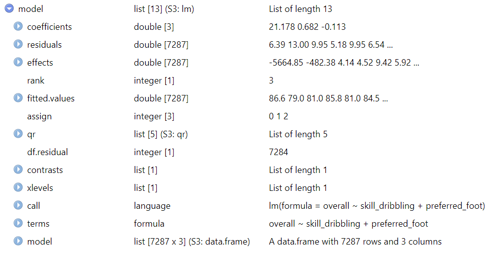

**Task 5:** Complete the code below. Use the correct subsetting operator for data extraction. Calculate residual sum of squares (RSS) — an absolute measure of model error — and root mean squared error (RMSE) metrics, a relative measure of model error. Explain which metric is used in which case. Explain what actually mean RMSE in the context of your data.

```r
residuals <- ... # Extract residuals from the model object
RSS <- ... # Calculate residual sum of squares
RMSE <- ... # Calculate residual root mean squared error

RSS ; RMSE # Print RSS and RMSE
```

```
## [1] 103919.1
```

```
## [1] 3.77636
```

Interpret RSS and adjusted RMSE. Is, or should be RMSE different from the residual standard error?

### Inspecting Residuals

When applied to an object of a regression model, `plot()` displays the analysis of residuals. It is always good to inspect these data to make sure that your theoretical assumptions are valid enough to trust the p-values produced by the model. `plot()` can create up to six plots, three of which are shown below.

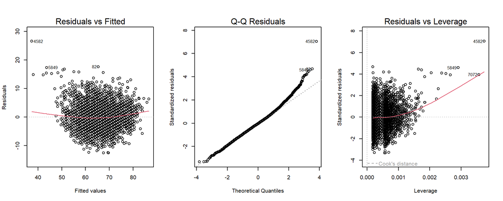

```r
par(mfrow = c(1,3)) # par() sets up a plotting grid: 1 row x 3 columns
plot(model, which = c(1,2,5))
```

- The 1<sup>st</sup> plot **Residuals vs. Fitted** checks for homoscedasticity (aka homogeneity of residual variances). What you do not want to get here is a funnel shape, meaning that the variance increases along increasing fitted points. We do not have anything like that here. The spindle shape it’s not perfect, but as close as it gets in real life.
- The 2<sup>nd</sup> plot **Quantile-Quantile Residuals** confirms that residuals are *normally* distributed, albeit not perfectly.
- The 3<sup>rd</sup> plot **Residuals vs. Leverage** is used to identify outliers and high leverage points. Quick glance tells us that there are very few data points that can affect model fit and we should not worry.

### Predicting New Data

One advantage of storing regression models as object is for using them to make predictions on new data. New data can come from observations that are not available at the time of model training. To make predictions on new data, use the `predict()` function.

R is also an object-oriented language, as is a functional one. Model objects in R have associated functions that operate on data stored within them. `predict()` is one of them.

Let’s predict an overall score for a super a left-footed player with dribbling skill of 100. Note that column names must be exactly the same as in the training data.

```r
newData <- tibble(skill_dribbling = 100, preferred_foot = "Left")
predict(model, newdata = newData)
```

```
##        1
## 89.33936
```

**Task 6:** Think about other built-in functions that are used to extract data from model objects. What are they? Research web to find out.